# International Mortality Tables Overview

2023-10-27

```r
library(tidyverse, quietly = TRUE)
library(MortalityTables)
mortalityTables.load("Austria_Census")
```

# 1 Austria

## 1.1 Annuities

Annuity tables in Austria are traditionally published by the [Actuarial Association of Austria (AVÖ)](https://avoe.at/rechnungsgrundlagen/).

### 1.1.1 ÖVM 59/61 - RR 67

[TODO: Get actual table data and publication]

- Source: H. Nabl: ÖVM 59/61 - RR67 - 3%, Die Versicherungsrundschau, 22. Jahrgang, Heft 12, Dez. 1967, p.373–380.

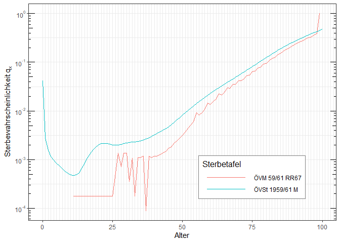

```r
mortalityTables.load("Austria_Annuities_RR67")
plotMortalityTables(RR67, mort.AT.census.1961.male)
```

### 1.1.2 EROM/F 85 (Period table 2020), EROM/F G 1950 (Cohort table with age shift)

- EROM/F 85: gender-specific period tables, projected to year 2020 to account for mortality improvement
  - male+female, ages 0-99
- EROM/F G 1950: gender-specific cohort tables, base cohort 1950 with age-shifting to account for mortality improvement
  - male+female, ages 0-99
- Derived from population mortalities 1980/82 (improvements from population mortalities 1949/51 and 1980/82), with annuitants’ selection factors applied
- First-order table without explicit security loadings
- Usage: Individual Annuity pricing and reserving
- Publisher: Aktuarvereinigung Österreichs (AVÖ), https://avoe.at/
- Target collective: Individual annuitants
- Usage with the `MortalityTables` package:

```r
mortalityTables.load("Austria_Annuities_EROMF")
EROM85.male
EROF85.female

EROM.G1950.male
EROM.G1950.male.av
EROF.G1950.female
EROF.G1950.female.av
```

- Source: F.G. Liebmann, W. Schachermayer, M. Willomitzer: Zur Erstellung von Sterbetafeln EROM 85 und EROF 85, Mitteilungen der Aktuarvereinigung Österreichs, Heft 4, Dezember 1986, p. 1–52.
- Source: F.G. Liebmann, W. Schachermayer, M. Willomitzer: Die Generationen-Sterbetafeln EROM G 1950 und EROF G 1950, Mitteilungen der Aktuarvereinigung Österreichs, Heft 4, Dezember 1986, p. 54–94.

### 1.1.3 AVÖ 1996-R

- gender-specific cohort tables with age-specific trend to account for mortality improvement (approximation via age-shifting given alternatively)
  - male+female, ages 0-112, individual and group variants
- Derived from population mortalities 1990/92 with annuitants’ selection factors applied
  - Trend factors derived from short-term population trend 1980–95 and long-term population trend 1865–1990
- First-order table without explicit security loadings
- Usage: Individual and Group Annuity pricing and reserving; Minimum required by Austrian Financial Authority until publication of successor table AVÖ 2005R
- Publisher: Aktuarvereinigung Österreichs (AVÖ), https://avoe.at/
- Target collective: Individual and group annuitants
- Usage with the `MortalityTables` package:

```r
mortalityTables.load("Austria_Annuities_AVOe1996R")
AVOe1996R
AVOe1996R.male
AVOe1996R.male.av325
AVOe1996R.male.group
AVOe1996R.female
AVOe1996R.female.av325
AVOe1996R.female.group
```

- Source: S. Jörgen, F.G. Liebmann, F.W. Pagler, W. Schachermayer: Herleitung der Sterbetafel AVÖ 1996R für Rentenversicherungen, Mitteilungen der Aktuarvereinigung Österreichs, Heft 9, November 1997, p. 39–82.

### 1.1.4 AVÖ 2005-R

```r
mortalityTables.load("Austria_Annuities_AVOe2005R")
AVOe2005R
AVOe2005R.male
AVOe2005R.male.group
AVOe2005R.male.av
AVOe2005R.male.group.av
AVOe2005R.male.unloaded
AVOe2005R.male.nodamping
AVOe2005R.male.nodamping.group
AVOe2005R.male.nodamping.unloaded

AVOe2005R.female
AVOe2005R.female.group
AVOe2005R.female.av
AVOe2005R.female.group.av
AVOe2005R.female.unloaded
AVOe2005R.female.nodamping
AVOe2005R.female.nodamping.group
AVOe2005R.female.nodamping.unloaded

AVOe2005R.unisex
AVOe2005R.unisex.group
AVOe2005R.unisex.av
AVOe2005R.unisex.group.av
AVOe2005R.unisex.nodamping
AVOe2005R.unisex.nodamping.group
```

- Sources:
  - R. Kainhofer, M. Predota, U. Schmock: [The New Austrian Annuity Valuation Table AVÖ 2005R](https://avoe.at/rententafel-avoe-2005r/), Mitteilungen der Aktuarvereinigung Österreichs, Heft 13, pp.55–135, https://avoe.at/pdf/mitteilungen/H13_w3.pdf
  - Aktuarvereinigung Österreichs: [Konstruktion der Unisex-Rententafel AVÖ 2005 R unisex](https://avoe.at/rententafel-avoe-2005r-unisex/, 2012
  - R. Kainhofer: [Zur Angemessenheit der Rententafel AVÖ 2005-R](https://avoe.at/zur-angemessenheit-der-rententafel-avoe-2005-r/, Arbeitskreis Rechnungsgrundlagen, Aktuarvereinigung Österreichs (AVÖ), 24.Oktober 2019

### 1.1.5 Comparisons

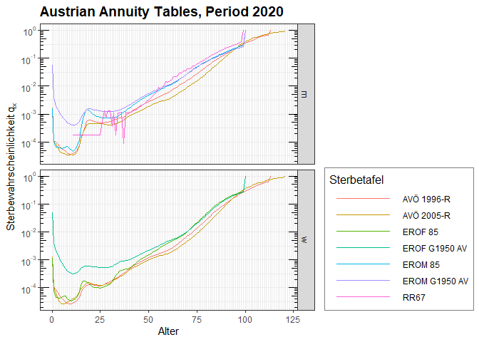

```r
plotMortalityTables(RR67, EROM85.male, EROF85.female, EROM.G1950.male.av, EROF.G1950.female.av, AVOe1996R[, "Einzel"], AVOe2005R[c("m", "w"), "Einzel","loaded"],
                    aes = aes(color = year), Period = 2020, title = "Austrian Annuity Tables, Period 2020",
                    legend.position = "right"
) + facet_grid(sex ~ .)
```

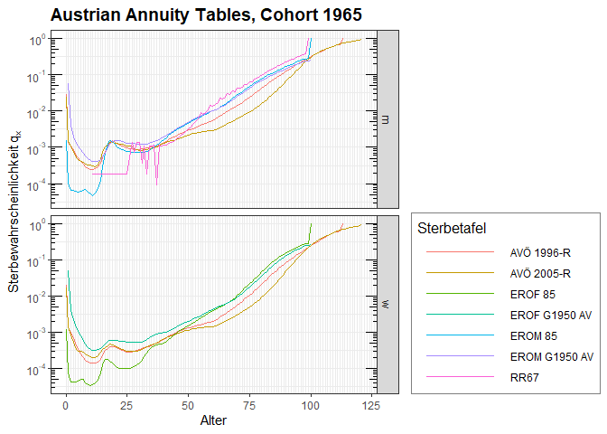

```r
plotMortalityTables(RR67, EROM85.male, EROF85.female, EROM.G1950.male.av, EROF.G1950.female.av, AVOe1996R[, "Einzel"],AVOe2005R[c("m", "w"), "Einzel","loaded"],
                    aes = aes(color = year), YOB = 1965, title = "Austrian Annuity Tables, Cohort 1965",
                    legend.position = "right"
) + facet_grid(sex ~ .)
```

## 1.2 Population Mortality (Austrian Census tables)

#### 1.2.0.1 Census tables

- gender-specific period tables
  - male+female, unisex only starting 2000/02; ages 0–95, from 1930 on 0–100
- Based on the official census data:
  - 1868/71
  - 1879/82
  - 1889/92
  - 1899/1902
  - 1909/12
  - 1930/33
  - 1949/51
  - 1959/61
  - 1970/72
  - 1980/82
  - 1990/92
  - 2000/02
  - 2010/12
  - 2020/22
- Usage with the `MortalityTables` package:

```r
mortalityTables.load("Austria_Census")
mort.AT.census
```

```
#>           Jahr
#> Geschlecht 1869
#>          m <S4 class 'mortalityTable.period' [package "MortalityTables"] with 8 slots>
#>          w <S4 class 'mortalityTable.period' [package "MortalityTables"] with 8 slots>
#>          u NA
#>           Jahr
#> Geschlecht 1880
#>          m <S4 class 'mortalityTable.period' [package "MortalityTables"] with 8 slots>
#>          w <S4 class 'mortalityTable.period' [package "MortalityTables"] with 8 slots>
#>          u NA
#>           Jahr
#> Geschlecht 1890
#>          m <S4 class 'mortalityTable.period' [package "MortalityTables"] with 8 slots>
#>          w <S4 class 'mortalityTable.period' [package "MortalityTables"] with 8 slots>
#>          u NA
#>           Jahr
#> Geschlecht 1900
#>          m <S4 class 'mortalityTable.period' [package "MortalityTables"] with 8 slots>
#>          w <S4 class 'mortalityTable.period' [package "MortalityTables"] with 8 slots>
#>          u NA
#>           Jahr
#> Geschlecht 1910
#>          m <S4 class 'mortalityTable.period' [package "MortalityTables"] with 8 slots>
#>          w <S4 class 'mortalityTable.period' [package "MortalityTables"] with 8 slots>
#>          u NA
#>           Jahr
#> Geschlecht 1931
#>          m <S4 class 'mortalityTable.period' [package "MortalityTables"] with 8 slots>
#>          w <S4 class 'mortalityTable.period' [package "MortalityTables"] with 8 slots>
#>          u NA
#>           Jahr
#> Geschlecht 1951
#>          m <S4 class 'mortalityTable.period' [package "MortalityTables"] with 8 slots>
#>          w <S4 class 'mortalityTable.period' [package "MortalityTables"] with 8 slots>
#>          u NA
#>           Jahr
#> Geschlecht 1961
#>          m <S4 class 'mortalityTable.period' [package "MortalityTables"] with 8 slots>
#>          w <S4 class 'mortalityTable.period' [package "MortalityTables"] with 8 slots>
#>          u NA
```

[output cut: 15 more lines]

```
#>           Jahr
#> Geschlecht 2001
#>          m <S4 class 'mortalityTable.period' [package "MortalityTables"] with 8 slots>
#>          w <S4 class 'mortalityTable.period' [package "MortalityTables"] with 8 slots>
#>          u <S4 class 'mortalityTable.mixed' [package "MortalityTables"] with 9 slots>
#>           Jahr
#> Geschlecht 2011
#>          m <S4 class 'mortalityTable.period' [package "MortalityTables"] with 8 slots>
#>          w <S4 class 'mortalityTable.period' [package "MortalityTables"] with 8 slots>
#>          u <S4 class 'mortalityTable.period' [package "MortalityTables"] with 8 slots>
#>           Jahr
#> Geschlecht 2021
#>          m <S4 class 'mortalityTable.period' [package "MortalityTables"] with 8 slots>
#>          w <S4 class 'mortalityTable.period' [package "MortalityTables"] with 8 slots>
#>          u <S4 class 'mortalityTable.period' [package "MortalityTables"] with 8 slots>
```

- Source: [Statistik Austria](http://statistik.at/web_de/statistiken/menschen_und_gesellschaft/bevoelkerung/sterbetafeln/index.html), http://statistik.at/wcm/idc/idcplg?IdcService=GET_NATIVE_FILE&RevisionSelectionMethod=LatestReleased&dDocName=022541

### 1.2.1 Official population forecast (by Statistik Austria)

- Gender-specific forecast (middle scenario) of the mortalities to 2080
- Provided by Statistik Austria (no formal publication of the tables), can be used freely with attribution
- Usage with the `MortalityTables` package:

```r
mortalityTables.load("Austria_PopulationForecast")
mort.AT.forecast
mortalityTables.load("Austria_PopulationObserved")
```

### 1.2.2 Markov-Chain-Monte-Carlo-fitted population forecast (by J. Hirz)

- Gender-specific forecast (middle scenario) of the mortalities by a MCMC-fit of age-specific trend factors
- Derived for the Austrian pension Table AVÖ 2018-P.
- Creator: Jonas Hirz
- Usage with the `MortalityTables` package:

```r
mortalityTables.load("Austria_PopulationMCMC")
mort.AT.MCMC
```

- Source: R. Kainhofer, J. Hirz, A. Schubert: AVÖ 2018-P - Rechnungsgrundlagen für die Pensionsversicherung, Dokumentation der Pensionstafel, Arbeitskreis Rechnungsgrundlagen, Aktuarvereinigung Österreichs (AVÖ), 30. August 2018. https://oefdv.avoe.at/rechnungsgrundlagen/

### 1.2.3 Observed population mortalities 1947–2022 (by Statistik Austria)

- Gender-specific observations of the mortalities from 1947
- Provided by Statistik Austria (no formal publication of the tables), can be used freely with attribution
- Usage with the `MortalityTables` package:

```r
mortalityTables.load("Austria_PopulationObserved")
mort.AT.observed.male
mort.AT.observed.female
mort.AT.observed.unisex
```

### 1.2.4 Comparison

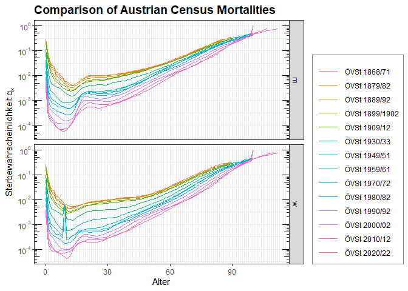

```r
plotMortalityTables(
  mort.AT.census[c("m", "w"),],

  aes = aes(color = table),
  legend.position = "right", legend.key.width = unit(2, "lines"),
  title = "Comparison of Austrian Census Mortalities"
) + labs(color = NULL) + facet_grid(sex ~ .)
```

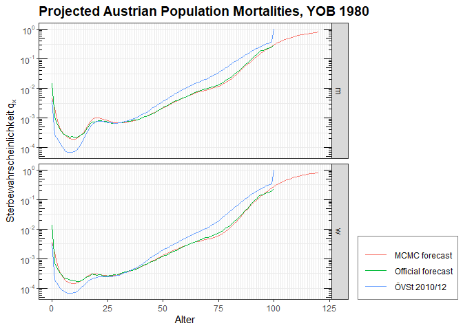

```r
plotMortalityTables(
  mort.AT.census[c("m", "w"),"2011"],
  mort.AT.forecast %>% mT.setDimInfo(table = "Official forecast"),
  mort.AT.MCMC[c("m", "w")] %>% mT.setDimInfo(table = "MCMC forecast"),

  YOB = 1980,
  aes = aes(color = table),
  legend.position = "right", legend.key.width = unit(2, "lines"),
  title = "Projected Austrian Population Mortalities, YOB 1980"

) + labs(color = NULL) + facet_grid(sex ~ .)
```

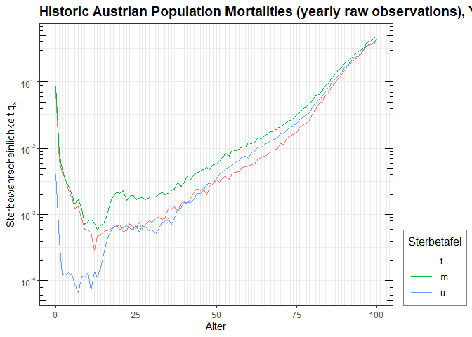

```r
plotMortalityTables(
  mort.AT.observed.male,
  mort.AT.observed.female,
  mort.AT.observed.unisex,

  YOB = 1940,
  aes = aes(color = sex),
  legend.position = "right", legend.key.width = unit(2, "lines"),
  title = "Historic Austrian Population Mortalities (yearly raw observations), YOB 1940"
)

```

## 1.3 Occupational Pensions

### 1.3.1 Ettl-Pagler

- gender-specific period tables for active and disabled persons (also transitions), as well as pensioners and widows
- second-order table, describing the transition probabilities of the Austrian social security system

```r
# pensionTables.load("Austria_EttlPagler")
# EttlPagler.male
# EttlPagler.female
```

- Source: Ettl W. und Pagler F.: “Rechnungsgrundlagen für die Pensionsversicherung”, Verlag: Verband der wissenschaftlichen Gesellschaften Österreichs, Wien, 1989

### 1.3.2 AVÖ 1999-P - Rechnungsgrundlagen für die Pensionsversicherung - Pagler-Pagler

- gender-specific period tables for active and disabled persons (also transitions), as well as pensioners and widows
  - 2 Variants: “P” for pension reserves, “PK” for pension funds
  - 2 collectives: White-collar workers (“Angestellte”) and mixed collective of white- and blue-collar workers
- second-order table, describing the transition probabilities of the Austrian social security system
- Publisher: Aktuarvereinigung Österreichs (AVÖ), Creator: Pagler & Pagler
- No documentation available

```r
# pensionTables.load("Austria_AVOe1999P")
# AVOe1999P
```

### 1.3.3 AVÖ 2008-P - Rechnungsgrundlagen für die Pensionsversicherung - Pagler-Pagler

- gender-specific period tables for active and disabled persons (also transitions), as well as pensioners and widows
  - 2 Variants: “P” for pension reserves, “PK” for pension funds
  - 2 collectives: White-collar workers (“Angestellte”) and mixed collective of white- and blue-collar workers
- second-order table, describing the transition probabilities of the Austrian social security system
- Publisher: Aktuarvereinigung Österreichs (AVÖ), Creator: Pagler & Pagler
- No documentation available

```r
# pensionTables.load("Austria_AVOe2008P")
# AVOe2008P
```

### 1.3.4 AVÖ 2018-P - Rechnungsgrundlagen für die Pensionsversicherung

- gender-specific period tables for active and disabled persons (also transitions), as well as pensioners and widows
  - 2 Variants: “Rehageld” (“rehab money”) considered as invalidity or considered as active
  - 2 collectives: White-collar workers (“Angestellte”) and mixed collective of white- and blue-collar workers
- second-order table, describing real the transition probabilities of the Austrian social security system (2000/2010 – 2016)
- Publisher: Aktuarvereinigung Österreichs (AVÖ), Creator: R. Kainhofer, J. Hirz, A. Schubert

```r
# pensionTables.load("Austria_AVOe2018P")
# AVOe2018P
```

- Source: R. Kainhofer, J. Hirz, A. Schubert: AVÖ 2018-P - Rechnungsgrundlagen für die Pensionsversicherung, Dokumentation der Pensionstafel, Arbeitskreis Rechnungsgrundlagen, Aktuarvereinigung Österreichs (AVÖ), 30. August 2018. https://oefdv.avoe.at/rechnungsgrundlagen/

## 1.4 Experience Tables

### 1.4.1 Gesamtbestand (total portfolio) of life insurance companies 2012–16

- gender-specific experience tables (period tables for 2012–16, central year 2014) for the whole Austrian insurance portfolio
  - separated into tradiional and unit-linlked contracts
- Experience mortality and lapse rates for the total portfolio of all Austrian Life insurance companies, 2012-2016
- Publisher: Aktuarvereinigung Österreichs (AVÖ)
- Creator: G. Friesacher, Th. Spanninger, R. Kainhofer Usage with the `MortalityTables` package:

```r
mortalityTables.load("Austria_VUGesamtbestand_2012-16")
VU.Gesamtbestand
VU.Gesamtbestand.Storno
VU.Gesamtbestand.Detail
```

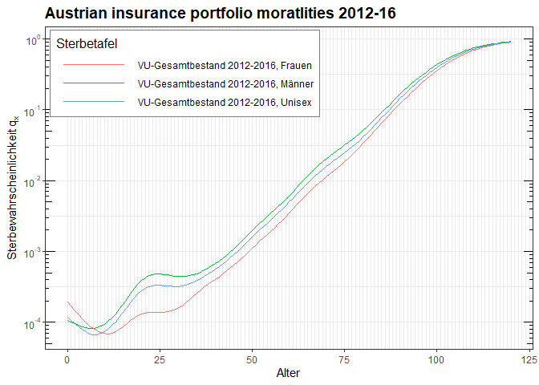

```r
plotMortalityTables(VU.Gesamtbestand, legend.position = c(0.01, 0.99), legend.justification = c(0,1), title = "Austrian insurance portfolio moratlities 2012-16")
```

Source: G. Friesacher, Th. Spanninger, R. Kainhofer: Gesamtbestandstafel – Lebensversicherungsbestand in Österreich von 2012 bis 2016, Arbeitskreis Rechnungsgrundlagen, Aktuarvereinigung Österreichs (AVÖ), 24. Oktober 2019. https://avoe.at/referenzsterbetafel-und-stornovektor-des-gesamtbestands-2012-16/

### 1.4.2 Gesamtbestand (total portfolio) of Austrian Pension Funds (Pensionskassen) 2010–16

- gender-specific experienc tables (period tables for 2010–16, central year 2013) for the four largest Austrian pension funds
  - mortalities and lapse rates
- Experience mortality and lapse rates for the total portfolio of the four largest Austrian pension funds, 2010-2016
- Publisher: Aktuarvereinigung Österreichs (AVÖ)
- Creator: R. Kainhofer Usage with the `MortalityTables` package:

```r
# mortalityTables.load("Austria_PK-Bestand_2010-16")
# PKBestandstafel.2010.16
```

```r
# plotMortalityTables(PKBestandstafel.2010.16[,,"qx", "raw"], legend.position = "right", title = "Austrian pension fund mortalities 2010-16", aes = aes(color = type)) +
  # facet_grid(sex ~ .) + labs(color = "Collective")
```

# 2 Germany

Tables in use:

- Allgemeine Deutsche Sterbetafel 1924/26 – Endowments (until 1980s)
- Sterbetafel 1967 (modified Sterbetafel der BRD 1960/62) – Endowments (1970s-1980s)
- Sterbetafel 1986 – Endowments
- Sterbetafel 1986 T – Endowments (1980s–1994)
- DAV 1994-T – Endowments (1994–)
- Sterbetafel der BRD 1949/51 – Annuities (until 1980s)
- Sterbetafel 1987 R – Annuities (1980s–1994)
- DAV 1994-R – Annuities (1994–2004)
- DAV 2004-R – Annuities (2004–)

## 2.1 Annuities

### 2.1.1 Sterbetafel 1987 R

[TODO: Get table data!] * Source: Lühr, K.-H.: Neue Sterbetafeln für die Rentenversicherung, Blätter DGVM XVII (1986), 485–513. https://link.springer.com/article/10.1007/BF02808817

### 2.1.2 DAV 1994 R:

- gender-specific tables, Base table 2000 with age-specific trends
  - male+female, ages 0-111
- approximation using age-shifting is provided (central YOB 1955)
  - Usage with the `MortalityTables` package:

```r
mortalityTables.load("Germany_Annuities_DAV1994R")
DAV1994R.male
DAV1994R.male.av
DAV1994R.female
DAV1994R.female.av
```

- Source: [Deutsche Aktuarvereinigung (DAV)](https://aktuar.de/unsere-themen/lebensversicherung/Seiten/default.aspx), https://aktuar.de/unsere-themen/lebensversicherung/sterbetafeln/UT_LV_5.pdf
- Source: Schmithals B. und Schütz E. U. (1995): “Herleitung der DAV-Sterbetafel 1994 R für Rentenversicherungen”, Blätter der Deutschen Gesellschaft für Versicherungsmathematik, Band XXII, Heft 1

### 2.1.3 DAV 2004 R:

- gender-specific tables, Base table 1999 with age-specific trends
  - male+female, ages 0-121
- First- and Second-Order Tables are provided, as well as a reserving table for existing business (“Bestand” and “B20”)
- Variants Aggregate and Select tables (5 years) are provided
- Usage with the `MortalityTables` package: (only Aggregate tables)

```r
mortalityTables.load("Germany_Annuities_DAV2004R")
DAV2004R.male
DAV2004R.male.2Ord
DAV2004R.male.av
DAV2004R.male.av.2Ord
DAV2004R.female
DAV2004R.female.2Ord
DAV2004R.female.av
DAV2004R.female.av.2Ord
```

- Source: [Deutsche Aktuarvereinigung (DAV)](https://aktuar.de/unsere-themen/lebensversicherung/Seiten/default.aspx), https://aktuar.de/unsere-themen/lebensversicherung/sterbetafeln/2023-06-28_DAV-Richtlinie_Herleitung_DAV2004R.pdf

### 2.1.4 Comparison

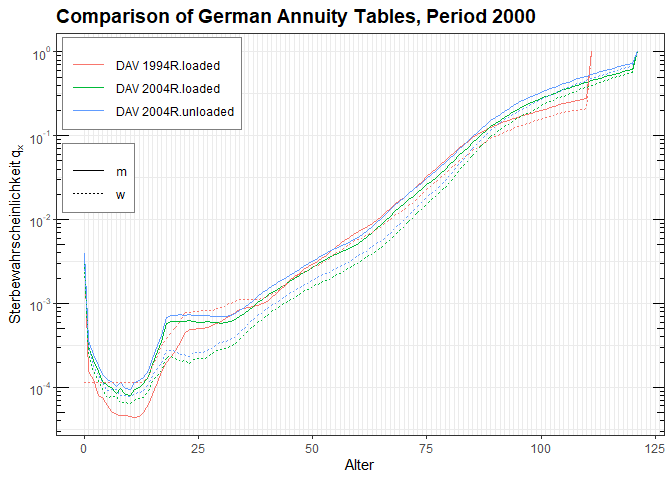

```r
plotMortalityTables(
  DAV1994R.male, DAV1994R.female,
  DAV2004R.male, DAV2004R.male.2Ord,
  DAV2004R.female, DAV2004R.female.2Ord,

  Period = 2000, aes = aes(linetype = sex, color = interaction(year, data)),
  legend.position = c(0.01, 0.99), legend.justification = c(0,1), legend.key.width = unit(2, "lines"),
  title = "Comparison of German Annuity Tables, Period 2000"
) + labs(linetype = NULL, color = NULL)
```

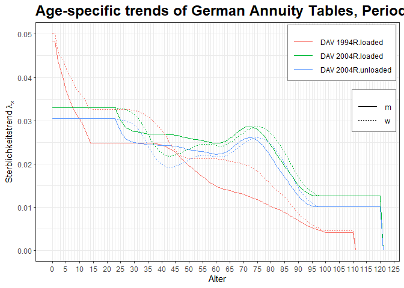

```r
plotMortalityTrend(
  DAV1994R.male, DAV1994R.female,
  DAV2004R.male, DAV2004R.male.2Ord,
  DAV2004R.female, DAV2004R.female.2Ord,

  Period = 2000, aes = aes(linetype = sex, color = interaction(year, data)),
  legend.position = c(0.99, 0.99), legend.justification = c(1,1), legend.key.width = unit(2, "lines"),
  title = "Age-specific trends of German Annuity Tables, Period 2000"
) + labs(linetype = NULL, color = NULL) + theme(legend.box.just = "right")
```

## 2.2 Population Mortality (German Census tables)

```r
mortalityTables.load("Germany_Census")
mort.DE.census
```

```
#>           Jahr
#> Geschlecht 1871/81
#>          m <S4 class 'mortalityTable.period' [package "MortalityTables"] with 8 slots>
#>          w <S4 class 'mortalityTable.period' [package "MortalityTables"] with 8 slots>
#>           Jahr
#> Geschlecht 1881/90
#>          m <S4 class 'mortalityTable.period' [package "MortalityTables"] with 8 slots>
#>          w <S4 class 'mortalityTable.period' [package "MortalityTables"] with 8 slots>
#>           Jahr
#> Geschlecht 1891/1900
#>          m <S4 class 'mortalityTable.period' [package "MortalityTables"] with 8 slots>
#>          w <S4 class 'mortalityTable.period' [package "MortalityTables"] with 8 slots>
#>           Jahr
#> Geschlecht 1901/10
#>          m <S4 class 'mortalityTable.period' [package "MortalityTables"] with 8 slots>
#>          w <S4 class 'mortalityTable.period' [package "MortalityTables"] with 8 slots>
#>           Jahr
#> Geschlecht 1910/11
#>          m <S4 class 'mortalityTable.period' [package "MortalityTables"] with 8 slots>
#>          w <S4 class 'mortalityTable.period' [package "MortalityTables"] with 8 slots>
#>           Jahr
#> Geschlecht 1924/26
#>          m <S4 class 'mortalityTable.period' [package "MortalityTables"] with 8 slots>
#>          w <S4 class 'mortalityTable.period' [package "MortalityTables"] with 8 slots>
#>           Jahr
#> Geschlecht 1932/34
#>          m <S4 class 'mortalityTable.period' [package "MortalityTables"] with 8 slots>
#>          w <S4 class 'mortalityTable.period' [package "MortalityTables"] with 8 slots>
#>           Jahr
#> Geschlecht 1949/51
#>          m <S4 class 'mortalityTable.period' [package "MortalityTables"] with 8 slots>
#>          w <S4 class 'mortalityTable.period' [package "MortalityTables"] with 8 slots>
#>           Jahr
#> Geschlecht 1960/62
#>          m <S4 class 'mortalityTable.period' [package "MortalityTables"] with 8 slots>
#>          w <S4 class 'mortalityTable.period' [package "MortalityTables"] with 8 slots>
#>           Jahr
#> Geschlecht 1970/72
#>          m <S4 class 'mortalityTable.period' [package "MortalityTables"] with 8 slots>
#>          w <S4 class 'mortalityTable.period' [package "MortalityTables"] with 8 slots>
#>           Jahr
#> Geschlecht 1986/88
#>          m <S4 class 'mortalityTable.period' [package "MortalityTables"] with 8 slots>
#>          w <S4 class 'mortalityTable.period' [package "MortalityTables"] with 8 slots>
```

- Source: Allgemeine Sterbetafeln, abgekürzte Sterbetafelnund Sterbetafeln, 1871/1881 bis 2008/2010. Wiesbaden. Statist. Bundesamt. Artikel 5126202109005, Mai 2012. https://www.statistischebibliothek.de/mir/receive/DESerie_mods_00002188

### 2.2.1 Comparison

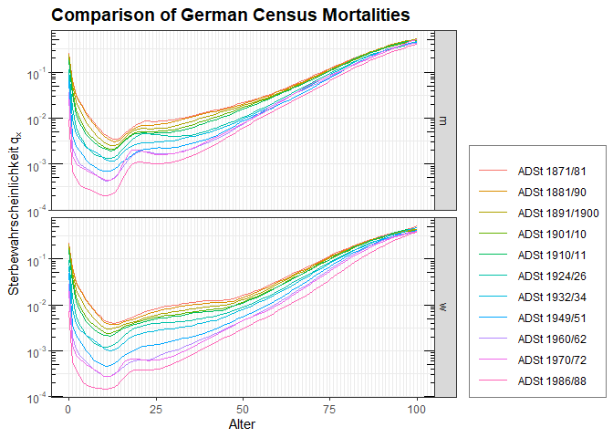

```r
plotMortalityTables(
  mort.DE.census,

  aes = aes(color = table),
  legend.position = "right", legend.key.width = unit(2, "lines"),
  title = "Comparison of German Census Mortalities"
) + labs(color = NULL) + facet_grid(sex ~ .)
```

## 2.3 Tables for contract with death characteristics (Life Insurances, Endowments)

### 2.3.1 Association Table of Assured Lives 1986

[TODO]

- Base on German Population Mortality Table 1981/83

### 2.3.2 DAV 1994 T

- gender-specific cohort table for German whole life insurances
- Based on the German Population Mortality Table 1986/88
- Generated: Deutsche Aktuarvereinigung (DAV), “Life-Insurance” committee
- Publisher: Deutsche Aktuarvereinigung (DAV), https://aktuar.de/unsere-themen/lebensversicherung/Seiten/default.aspx
- Usage with the `MortalityTables` package:

```r
mortalityTables.load("Germany_Endowments_DAV1994T")
DAV1994T.male
DAV1994T.male.2Ord
DAV1994T.female
DAV1994T.female.2Ord
```

- Source: H. Loebus: Bestimmung einer angemessenen Sterbetafel für Lebensversicherungen mit Todesfallcharakter, Blätter DGVM XXI (1994), 497–524. https://aktuar.de/unsere-themen/lebensversicherung/Seiten/default.aspx

### 2.3.3 DAV 2008 T, DAV 2008 T R/NR

- gender-specific cohort table for German whole life insurances
- Based on reinsurance data 2001–2004 (47 German insurance companies)
- Generated: Deutsche Aktuarvereinigung (DAV), “Life-Insurance” committee
- Publisher: Deutsche Aktuarvereinigung (DAV), https://aktuar.de/unsere-themen/lebensversicherung/Seiten/default.aspx
- Minimum standard prescribed by the DAV to be used for reserving unit-linked, endowment and whole life insurances in Germany
- Usage with the `MortalityTables` package:

```r
mortalityTables.load("Germany_Endowments_DAV2008T")
DAV2008T.male
DAV2008T.male.2Ord
DAV2008T.male.nonsmoker
DAV2008T.male.nonsmoker.2Ord
DAV2008T.male.smoker
DAV2008T.male.smoker.2Ord

DAV2008T.female
DAV2008T.female.2Ord
DAV2008T.female.nonsmoker
DAV2008T.female.nonsmoker.2Ord
DAV2008T.female.smoker
DAV2008T.female.smoker.2Ord
```

- Source: Herleitung der Sterbetafel DAV 2008 T für Lebensversicherungen mit Todesfallcharakter, [Deutsche Aktuarvereinigung (DAV)](https://aktuar.de/unsere-themen/lebensversicherung/Seiten/default.aspx), 22.11.2008. https://aktuar.de/unsere-themen/lebensversicherung/sterbetafeln/2022-11-29_DAV-Richtlinie_Herleitung_DAV2008T.pdf
- Source: Raucher- und Nichtrauchersterbetafeln für Lebensversicherungen mit Todesfallcharakter, [Deutsche Aktuarvereinigung (DAV)](https://aktuar.de/unsere-themen/lebensversicherung/Seiten/default.aspx), 22.11.2008. https://aktuar.de/unsere-themen/lebensversicherung/sterbetafeln/2022-11-29_DAV-Richtlinie_Herleitung_DAV2008T_R_NR.pdf

### 2.3.4 Comparisons

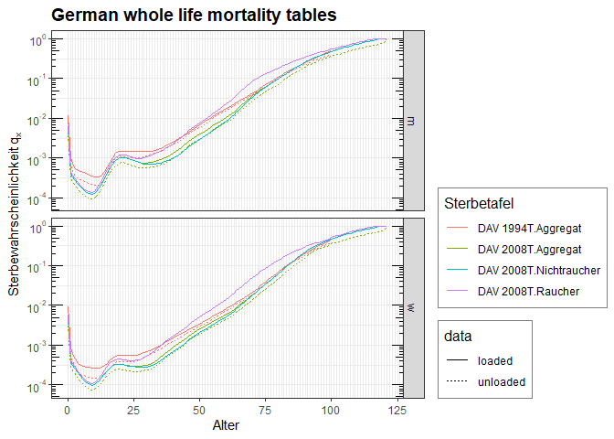

```r
plotMortalityTables(
  DAV1994T.male, DAV1994T.male.2Ord, DAV2008T.male, DAV2008T.male.2Ord, DAV2008T.male.nonsmoker,  DAV2008T.male.smoker,
  DAV1994T.female, DAV1994T.female.2Ord, DAV2008T.female, DAV2008T.female.2Ord, DAV2008T.female.nonsmoker,  DAV2008T.female.smoker,
  aes = aes(color = interaction(year, collar), linetype = data), legend.position = "right", legend.key.width = unit(1.5, "lines"),
  title = "German whole life mortality tables"
) + facet_grid(sex ~ .)
```

## 2.4 Occupational Disability

### 2.4.1 DAV 1997 I

[TODO] https://aktuar.de/unsere-themen/lebensversicherung/Seiten/default.aspx

- Source: Kolster N., Loebus H. und Mörtlbauer W. (1998): “Neue Rechnungsgrundlagen für die Berufsunfähigkeitsversicherung DAV 1997”, Blätter der Deutschen Gesellschaft für Versicherungsmathematik, Band XXIII, Heft 4

### 2.4.2 DAV 1998 EU

[TODO] https://aktuar.de/unsere-themen/lebensversicherung/Seiten/default.aspx

### 2.4.3 DAV 2001 EM/EM-T

[TODO] https://aktuar.de/unsere-themen/lebensversicherung/Seiten/default.aspx

## 2.5 MTPL Annuities

### 2.5.1 DAV 2006 HUR

[TODO] https://aktuar.de/unsere-themen/lebensversicherung/Seiten/default.aspx

## 2.6 Old-Age Care

[TODO]

### 2.6.1 DAV 2008 P

[TODO]

## 2.7 Occupational Pensions

### 2.7.1 Heubeck Richttafeln 1959

[TODO]

- Source: G. Heubeck, K. Fischer: Richttafeln für die Pensionsversicherung, René Fischer Verlag, Weissenburg/Bayern, 1959

### 2.7.2 Heubeck Richttafeln 1983

[TODO]

- Source: Heubeck K.: “Richttafeln”, Verlag: Heubeck-Richttafeln-GmbH, Köln, 1983

### 2.7.3 Heubeck Richttafeln 1998

[TODO]

- Source: Heubeck K.: “Richttafeln 1998”, Verlag Heubeck-Richttafeln-GmbH, Köln, 1998

### 2.7.4 Richttafeln DAV 2005-G

[TODO]

https://aktuar.de/unsere-themen/lebensversicherung/Seiten/default.aspx

- Source: Klaus Heubeck, Richard Herrmann und Gabriele D’Souza. „Die Richttafeln 2005 G – Modell, Herleitung, Formeln“. In: Blätter der DGVFM 27.3 (Apr. 2006), S. 473–517.

### 2.7.5 Heubeck Richttafeln 2018-G

[TODO]

# 3 United States of America

Source: [https://content.naic.org/sites/default/files/pbr_data_valuation_manual_current_edition.pdf] (Appendix M)

[TODO]

## 3.1 Annuities (individual and group)

## 3.2 Whole Life Insurances

## 3.3 Experience Tables

## 3.4 Pension Plans

### 3.4.1 RP-2000

### 3.4.2 RP-2014

Source: Society of Actuaries. RP-2014 Mortality Tables Report. Techn. Ber. Okt. 2014. URL: https://www.soa.org/experience-studies/2014/research-2014-rp/.

Source: Society of Actuaries. Mortality Improvement Scale MP-2014 Report. Techn. Ber. Okt. 2014. URL: https://www.soa.org/experience-studies/2014/research-2014-mp/.